# FinalPracticeTest

Jaclyn A Coate

8/10/2020

# Final Practice Test

Consider the data in the file: FinalExamData.csv. This file contains a column Xt and a column Zt. Your goal is to simply model this data the using a vector autoregressive model (VAR) and a multi-layer perceptron model (MLP). You ultimately want to forecast Xt with a horizon of 10 using Zt if it is useful. Provide the following information in your response:

```r
library(tswge)
library(vars)
library(nnfor)
library(forecast)
```

```r
final <- read.csv("https://raw.githubusercontent.com/BivinSadler/MSDS-6373-Time-Series/master/Unit%2015%20Final%20Exam/FinalExamData.csv", header = T)
head(final)
```

```
##   X       Xt        Zt
## 1 1 24.82257 10.981659
## 2 2 24.22416  8.136002
## 3 3 17.33310  7.144216
## 4 4 38.70274 11.951530
## 5 5 36.35362  6.907318
## 6 6 32.70639 10.035407
```

1. Identify the relationship/association between Xt and Zt. Specifically, is there evidence of a relationship/association between Xt and a lagged Zt? … if so, what is the lag?) What evidence do you have to support this relationship/association? (4 pts)

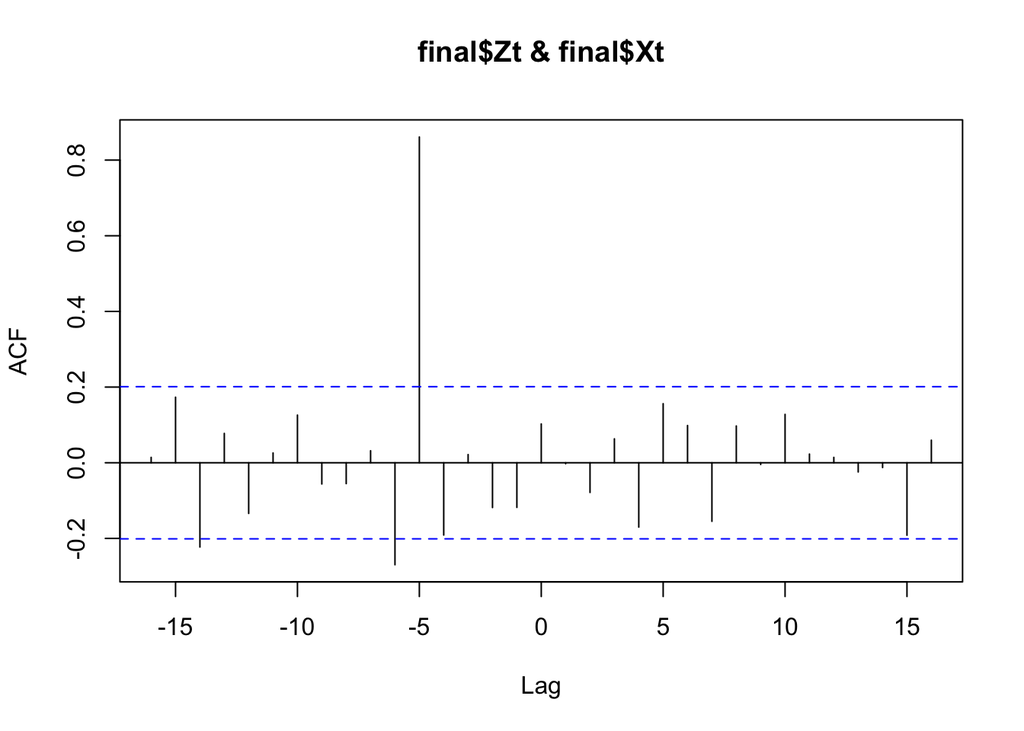

```r
ccf(final$Zt, final$Xt)
```

2. For each model (MLR w/ Correlated Errors / VAR / MLP) (10 pts each model):
3. Provide the code you used to fit the model and make the predictions.

### MLR w/ Correlated Errors

- Forecast Zt Variable

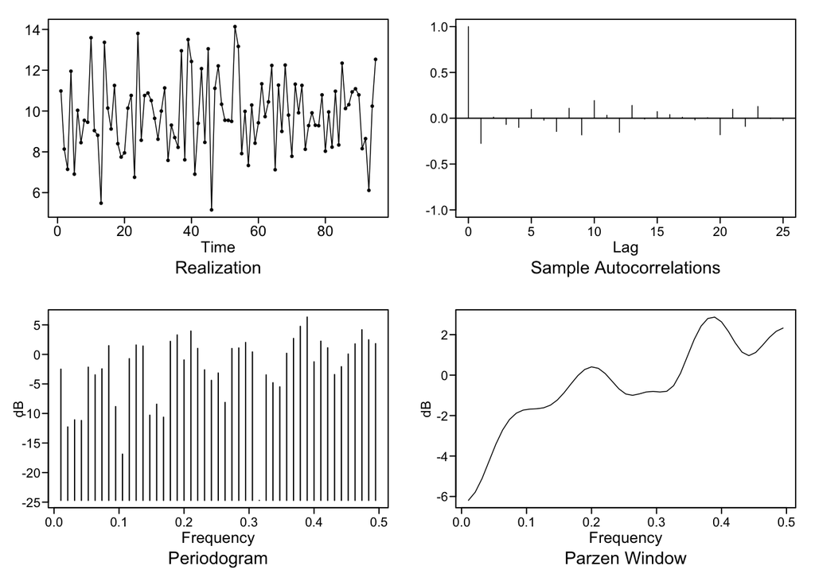

```
## $autplt
##  [1]  1.000000000 -0.274856165  0.012767409 -0.067733664 -0.100176077
##  [6]  0.096679961 -0.021784013 -0.144407025  0.108488420 -0.181835387
## [11]  0.193061059  0.032656600 -0.153527418  0.139999152 -0.008958327
## [16]  0.072477957  0.039924917  0.011436339 -0.018101125  0.006560065
## [21] -0.180107965  0.098217103 -0.089263635  0.128354519 -0.002996380
## [26] -0.023784337
##
## $freq
##  [1] 0.01052632 0.02105263 0.03157895 0.04210526 0.05263158 0.06315789
##  [7] 0.07368421 0.08421053 0.09473684 0.10526316 0.11578947 0.12631579
## [13] 0.13684211 0.14736842 0.15789474 0.16842105 0.17894737 0.18947368
## [19] 0.20000000 0.21052632 0.22105263 0.23157895 0.24210526 0.25263158
## [25] 0.26315789 0.27368421 0.28421053 0.29473684 0.30526316 0.31578947
## [31] 0.32631579 0.33684211 0.34736842 0.35789474 0.36842105 0.37894737
```

[output cut: 26 more lines]

```r
#Graph data for stationarity. There does not appear to be any violations of the 3 conditions
plotts.sample.wge(final$Zt)
```

```r
#Diagnose model with aic5.wge
aic5.wge(final$Zt) #AIC picks MA(1)
```

```
## ---------WORKING... PLEASE WAIT...
##
##
## Five Smallest Values of  aic
```

```
##      p    q        aic
## 2    0    1   1.238165
## 5    1    1   1.244128
## 4    1    0   1.249083
## 6    1    2   1.254821
## 3    0    2   1.255611
```

```r
aic5.wge(final$Zt, type = "bic") #BIC picks MA(1)
```

```
## ---------WORKING... PLEASE WAIT...
##
##
## Five Smallest Values of  bic
```

```
##      p    q        bic
## 2    0    1   1.291930
## 4    1    0   1.302849
## 5    1    1   1.324777
## 1    0    0   1.335846
## 3    0    2   1.336260
```

```r
#Test for white noise
ljung.wge(final$Zt)$pval #FTR Ho
```

```
## Obs -0.2748562 0.01276741 -0.06773366 -0.1001761 0.09667996 -0.02178401 -0.144407 0.1084884 -0.1818354 0.1930611 0.0326566 -0.1535274 0.1399992 -0.008958327 0.07247796 0.03992492 0.01143634 -0.01810113 0.006560065 -0.180108 0.0982171 -0.08926363 0.1283545 -0.00299638
```

```
## [1] 0.06815038
```

```r
ljung.wge(final$Zt, K = 48)$pval #FTR
```

```
## Obs -0.2748562 0.01276741 -0.06773366 -0.1001761 0.09667996 -0.02178401 -0.144407 0.1084884 -0.1818354 0.1930611 0.0326566 -0.1535274 0.1399992 -0.008958327 0.07247796 0.03992492 0.01143634 -0.01810113 0.006560065 -0.180108 0.0982171 -0.08926363 0.1283545 -0.00299638 -0.02378434 0.004934157 -0.02…
```

```
## [1] 0.3293116
```

```r
#Going w/ MA(1)
#Estimate phis and thetas w/ est.arma.wge
Zt.est = est.arma.wge(final$Zt, p = 0, q = 1)
predsZt = fore.arma.wge(final$Zt, theta = Zt.est$theta , n.ahead = 10)
```

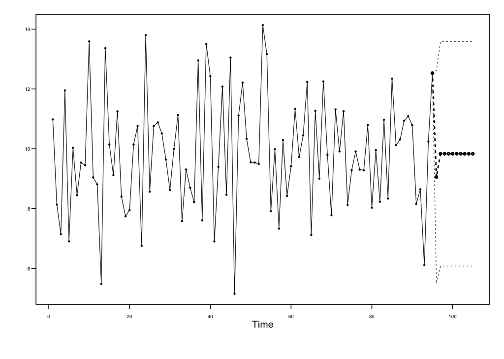

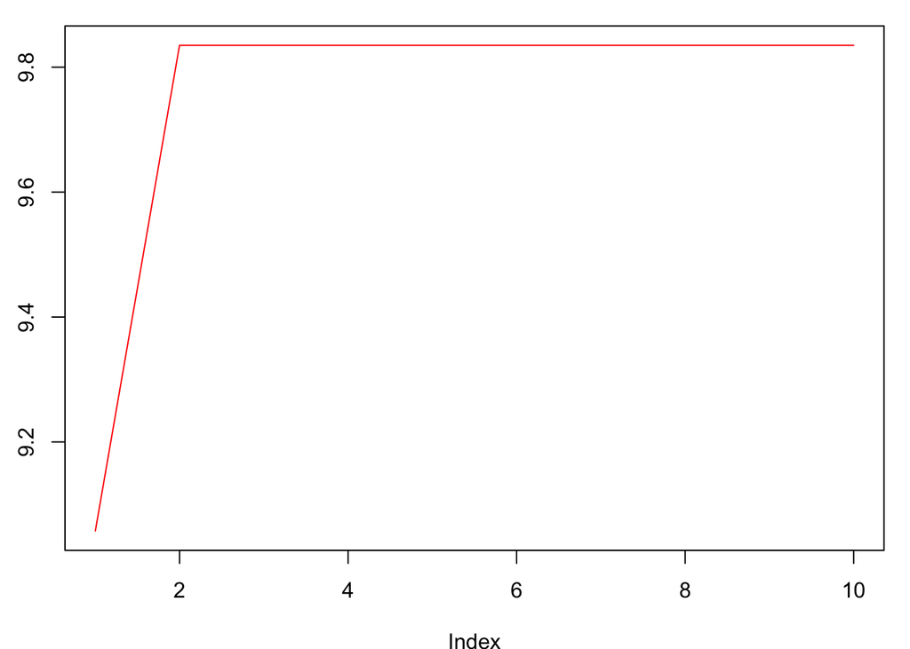

```r
#Plote predictions
plot(predsZt$f, type = "l", col = "red")
```

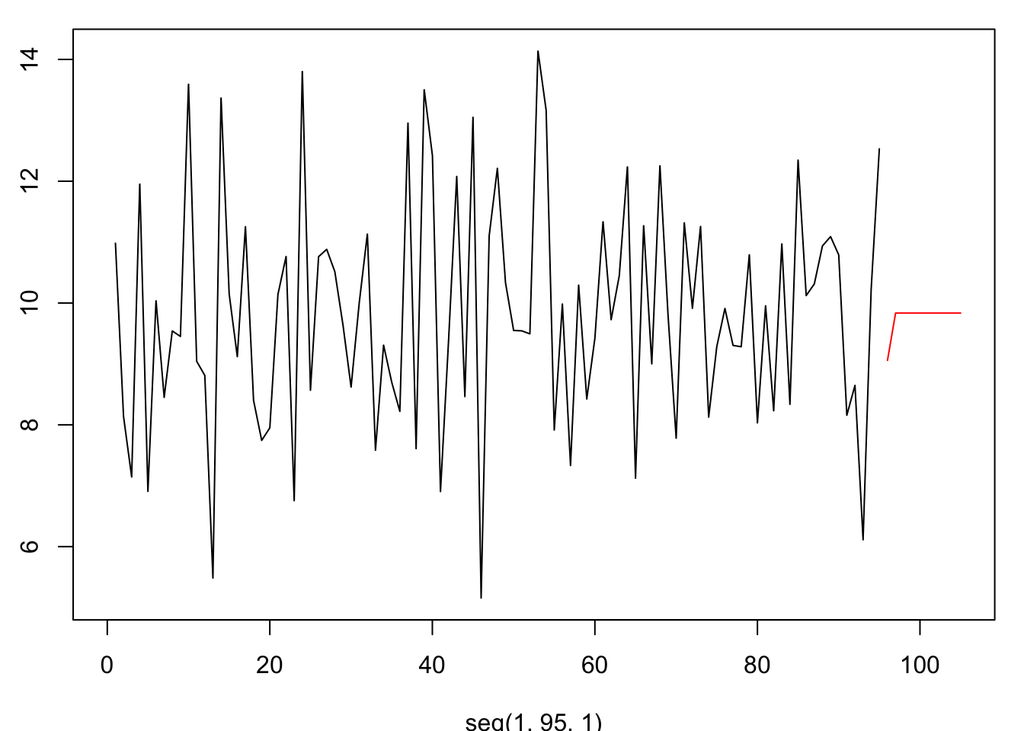

```r
#Graph Zt realization and 10 predictions
plot(seq(1,95,1), final$Zt, type = "l", xlim = c(0,105))
lines(seq(96,105,1), predsZt$f, type = "l", col = "red")
```

OR

```r
#MLP can be used to create predictions
#Create a time series object
tsZt <- ts(final$Zt)
#Fit MLP
fit.Zt <- nnfor::mlp(tsZt, reps = 50, comb = "mean")
fit.Zt
```

```
## MLP fit with 5 hidden nodes and 50 repetitions.
## Univariate lags: (1)
## Forecast combined using the mean operator.
## MSE: 3.0423.
```

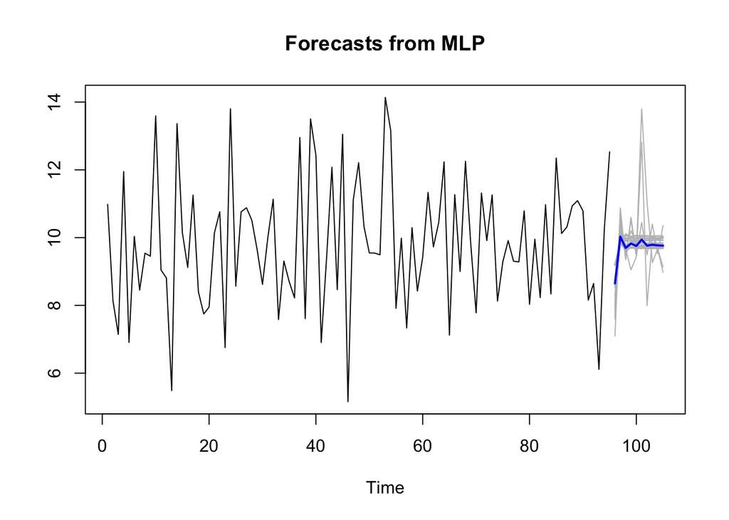

```r
fore.Zt <- forecast::forecast(fit.Zt, h=10)
plot(fore.Zt)
```

```r
fore.Zt$mean
```

```
## Time Series:
## Start = 96
## End = 105
## Frequency = 1
##       t+1       t+2       t+3       t+4       t+5       t+6       t+7
##  8.646644 10.029071  9.696492  9.823519  9.753145  9.940959  9.764621
##       t+8       t+9      t+10
##  9.790297  9.772044  9.764975
```

- Model Xt variable predicted Zt variable using MLR with Cor Erros
- We know there is a lag of -5

```r
#Lag Zt 5
final$lagZt = dplyr::lag(final$Zt,5)
final
```

```
##     X       Xt        Zt     lagZt
## 1   1 24.82257 10.981659        NA
## 2   2 24.22416  8.136002        NA
## 3   3 17.33310  7.144216        NA
## 4   4 38.70274 11.951530        NA
## 5   5 36.35362  6.907318        NA
## 6   6 32.70639 10.035407 10.981659
## 7   7 23.99093  8.450565  8.136002
## 8   8 22.18010  9.541315  7.144216
## 9   9 35.99741  9.451236 11.951530
## 10 10 22.17715 13.592128  6.907318
## 11 11 30.32880  9.043774 10.035407
## 12 12 23.53934  8.810474  8.450565
## 13 13 27.44868  5.484124  9.541315
## 14 14 26.95844 13.365214  9.451236
```

[output cut: 81 more lines]

- Create trend

```r
#t=1:95
#final$t = t
```

```r
lmfit = lm(Xt~lagZt, data = final) #+t if needing trend
```

- Check residuals
  - Reveal a frequency of .18, period 1/.18

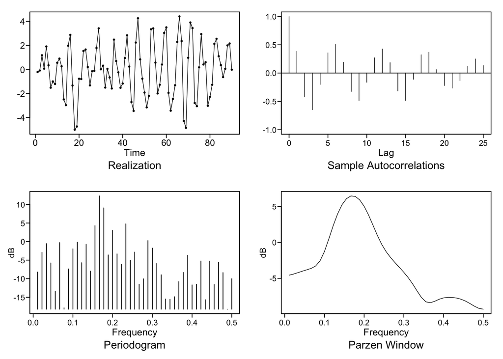

```
## $autplt
##  [1]  1.00000000  0.38539850 -0.42243234 -0.64900178 -0.20171215
##  [6]  0.35794016  0.50644982  0.19100272 -0.32556666 -0.48634817
## [11] -0.16379918  0.27089691  0.42592618  0.18479017 -0.31593690
## [16] -0.48485994 -0.11066432  0.32411379  0.36880658  0.06193774
## [21] -0.22064846 -0.26620639 -0.13394797  0.11972822  0.25034811
## [26]  0.13377449
##
## $freq
##  [1] 0.01111111 0.02222222 0.03333333 0.04444444 0.05555556 0.06666667
##  [7] 0.07777778 0.08888889 0.10000000 0.11111111 0.12222222 0.13333333
## [13] 0.14444444 0.15555556 0.16666667 0.17777778 0.18888889 0.20000000
## [19] 0.21111111 0.22222222 0.23333333 0.24444444 0.25555556 0.26666667
## [25] 0.27777778 0.28888889 0.30000000 0.31111111 0.32222222 0.33333333
## [31] 0.34444444 0.35555556 0.36666667 0.37777778 0.38888889 0.40000000
```

[output cut: 23 more lines]

```r
plotts.sample.wge(lmfit$residuals)
```

```r
acf(lmfit$residuals)
ljung.wge(lmfit$residuals[6:85])
```

```
## Obs 0.3859371 -0.4317017 -0.6634978 -0.2036431 0.3491694 0.4944928 0.1840944 -0.3104259 -0.4632191 -0.154568 0.2680476 0.417439 0.1859664 -0.2790436 -0.4475643 -0.1002339 0.2841492 0.3445019 0.08134453 -0.1750257 -0.2605734 -0.1687738 0.07943017 0.2329844
```

```
## $test
## [1] "Ljung-Box test"
##
## $K
## [1] 24
##
## $chi.square
## [1] 234.2514
##
## $df
## [1] 24
##
## $pval
## [1] 0
```

```r
ljung.wge(lmfit$residuals[6:85], K=48)
```

```
## Obs 0.3859371 -0.4317017 -0.6634978 -0.2036431 0.3491694 0.4944928 0.1840944 -0.3104259 -0.4632191 -0.154568 0.2680476 0.417439 0.1859664 -0.2790436 -0.4475643 -0.1002339 0.2841492 0.3445019 0.08134453 -0.1750257 -0.2605734 -0.1687738 0.07943017 0.2329844 0.1493311 -0.06675805 -0.2044814 -0.13929…
```

```
## $test
## [1] "Ljung-Box test"
##
## $K
## [1] 48
##
## $chi.square
## [1] 288.1749
##
## $df
## [1] 48
##
## $pval
## [1] 0
```

[figure not shown]

- Surface seasonality of 5.5, going to round up to 6 and difference data

```r
trans.resid <- artrans.wge(lmfit$residuals, c(0,0,0,0,0,1))
```

[figure not shown]

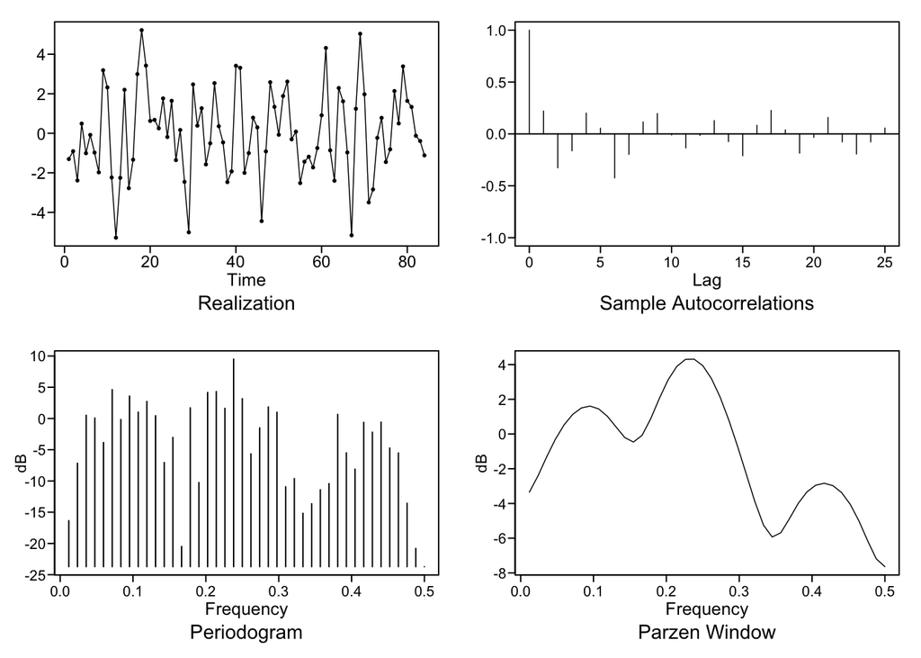

```
## $autplt
##  [1]  1.000000000  0.220938024 -0.326733514 -0.162811577  0.200964558
##  [6]  0.055395467 -0.424510104 -0.197199700  0.115423019  0.196480612
## [11] -0.009848193 -0.135470468 -0.014755435  0.128299258 -0.074570495
## [16] -0.209982408  0.083344320  0.226504101  0.039329896 -0.185132313
## [21] -0.032870994  0.158849295 -0.077023690 -0.194117907 -0.077303372
## [26]  0.056812042
##
## $freq
##  [1] 0.01190476 0.02380952 0.03571429 0.04761905 0.05952381 0.07142857
##  [7] 0.08333333 0.09523810 0.10714286 0.11904762 0.13095238 0.14285714
## [13] 0.15476190 0.16666667 0.17857143 0.19047619 0.20238095 0.21428571
## [19] 0.22619048 0.23809524 0.25000000 0.26190476 0.27380952 0.28571429
## [25] 0.29761905 0.30952381 0.32142857 0.33333333 0.34523810 0.35714286
## [31] 0.36904762 0.38095238 0.39285714 0.40476190 0.41666667 0.42857143
```

[output cut: 23 more lines]

```r
plotts.sample.wge(trans.resid)
```

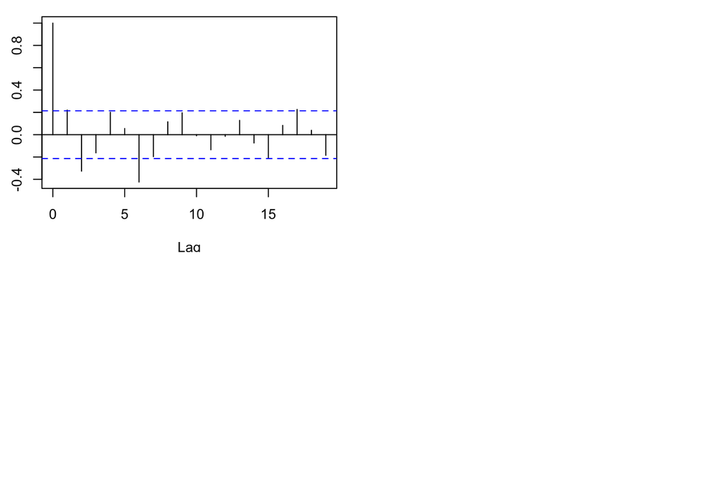

```r
acf(trans.resid)
```

- Diagnose fit and determine the phis and thetas on resdidauls from transformed data
  - AIC Selects ARMA(7,1)

```r
phisthetas = aic.wge(trans.resid, p = 0:8, q = 0:8)
phisthetas
```

```
## $type
## [1] "aic"
##
## $value
## [1] 1.268728
##
## $p
## [1] 7
##
## $q
## [1] 1
##
## $phi
## [1] -0.54958690 -0.02801802 -0.31751786 -0.03664155  0.06223568 -0.41540913
## [7] -0.23268070
##
## $theta
## [1] -0.9999966
##
## $vara
## [1] 2.870373
```

- Fit the arima model based on above fit
  - Seasonality from residual transformation above, for below equation

```r
fitarima = arima(final$Xt, order = c(7,0,1), seasonal = list(order = c(1,0,0), period = 6), xreg = final$lagZt)
fitarima
```

```
##
## Call:
## arima(x = final$Xt, order = c(7, 0, 1), seasonal = list(order = c(1, 0, 0),
##     period = 6), xreg = final$lagZt)
##
## Coefficients:
##           ar1      ar2      ar3      ar4     ar5     ar6     ar7     ma1
##       -0.1456  -0.1917  -0.4728  -0.0158  0.0334  0.2196  0.2221  0.6330
## s.e.   0.6083   0.3200   0.3225   0.1497  0.1066  0.1272  0.1666  0.6109
##          sar1  intercept  final$lagZt
##       -0.2627    -0.2306       3.0078
## s.e.   0.1402     0.5400       0.0527
##
## sigma^2 estimated as 1.847:  log likelihood = -156.4,  aic = 336.79
```

- AIC of fitted ARIMA

```r
AIC(fitarima)
```

```
## [1] 336.795
```

```r
predsXt = predict(fitarima, newxreg = fore.Zt$mean, n.ahead = 10) #add cbind(, time) if trend sign
predsXt
```

```
## $pred
## Time Series:
## Start = 96
## End = 105
## Frequency = 1
##  [1] 23.89438 28.50638 29.02321 30.48541 30.26031 29.71118 28.11332
##  [8] 28.21555 29.30302 30.25427
##
## $se
## Time Series:
## Start = 96
## End = 105
## Frequency = 1
##  [1] 1.359179 1.512067 1.553645 1.711413 1.719042 1.757344 1.780541
##  [8] 1.790184 1.802129 1.843617
```

```r
#Add predictions onto Zt column
#Ztwpreds <- data.frame(c(final$Zt, fore.Zt$mean))
#Ztwpreds
#time <- data.frame(c(final$t, t=96:105))
#time
```

#### VAR

- Graph Data
  - Upon grpahing the data we do not see extreme evidence of nonstationary components. We see that conditions 1 - 3 are tentatively met. We will assume stationarity.

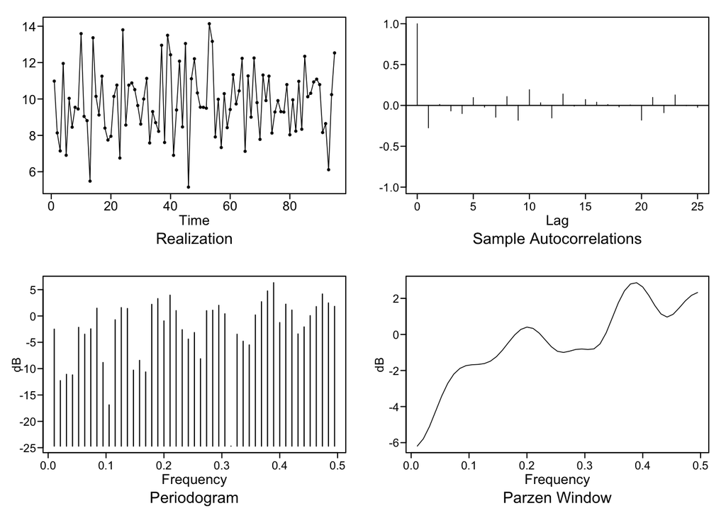

```
## $autplt
##  [1]  1.000000000 -0.274856165  0.012767409 -0.067733664 -0.100176077
##  [6]  0.096679961 -0.021784013 -0.144407025  0.108488420 -0.181835387
## [11]  0.193061059  0.032656600 -0.153527418  0.139999152 -0.008958327
## [16]  0.072477957  0.039924917  0.011436339 -0.018101125  0.006560065
## [21] -0.180107965  0.098217103 -0.089263635  0.128354519 -0.002996380
## [26] -0.023784337
##
## $freq
##  [1] 0.01052632 0.02105263 0.03157895 0.04210526 0.05263158 0.06315789
##  [7] 0.07368421 0.08421053 0.09473684 0.10526316 0.11578947 0.12631579
## [13] 0.13684211 0.14736842 0.15789474 0.16842105 0.17894737 0.18947368
## [19] 0.20000000 0.21052632 0.22105263 0.23157895 0.24210526 0.25263158
## [25] 0.26315789 0.27368421 0.28421053 0.29473684 0.30526316 0.31578947
## [31] 0.32631579 0.33684211 0.34736842 0.35789474 0.36842105 0.37894737
```

[output cut: 26 more lines]

```r
plotts.sample.wge(final$Zt)
```

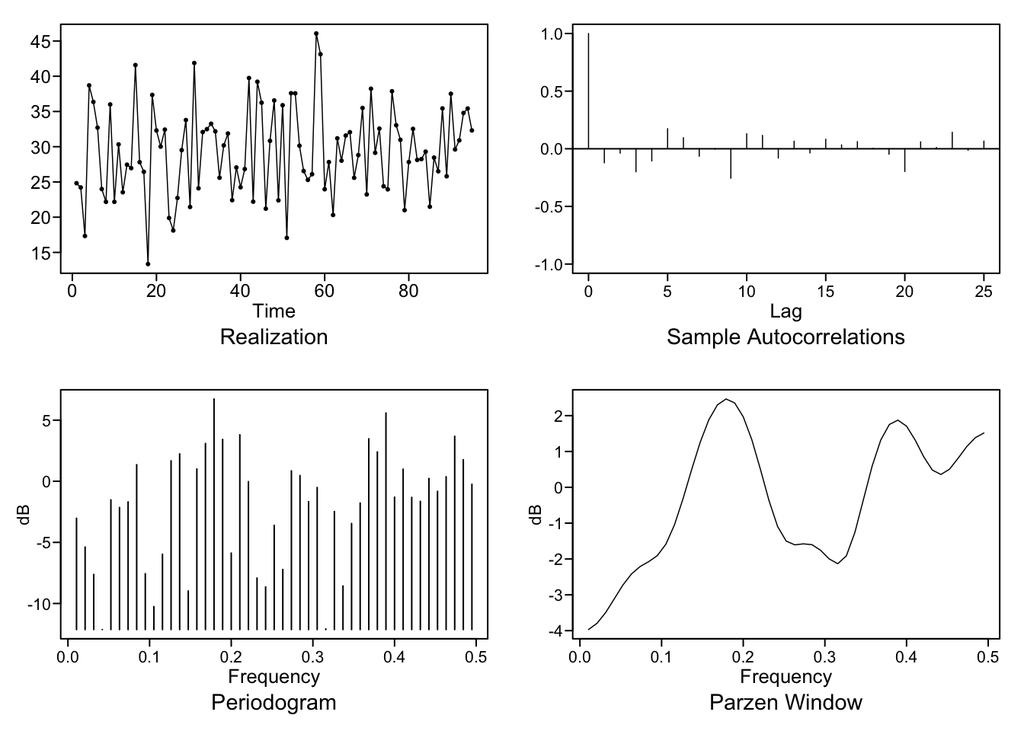

```
## $autplt
##  [1]  1.000000000 -0.122337479 -0.038052234 -0.199769974 -0.106096953
##  [6]  0.174563066  0.096370855 -0.064847187 -0.003271516 -0.256003197
## [11]  0.130585031  0.116242163 -0.080527953  0.065814614 -0.036426886
## [16]  0.083310138  0.033780033  0.062375214  0.004873376 -0.047691267
## [21] -0.197224938  0.060106077  0.011541330  0.143193774 -0.012670208
## [26]  0.066942910
##
## $freq
##  [1] 0.01052632 0.02105263 0.03157895 0.04210526 0.05263158 0.06315789
##  [7] 0.07368421 0.08421053 0.09473684 0.10526316 0.11578947 0.12631579
## [13] 0.13684211 0.14736842 0.15789474 0.16842105 0.17894737 0.18947368
## [19] 0.20000000 0.21052632 0.22105263 0.23157895 0.24210526 0.25263158
## [25] 0.26315789 0.27368421 0.28421053 0.29473684 0.30526316 0.31578947
## [31] 0.32631579 0.33684211 0.34736842 0.35789474 0.36842105 0.37894737
```

[output cut: 24 more lines]

```r
plotts.sample.wge(final$Xt)
```

- Using VARselect diagnose the data -AIC = 2.303725 for p = 7

```r
VARselect(cbind(final$Xt, final$Zt),lag.max = 10, type = "both")
```

```
## $selection
## AIC(n)  HQ(n)  SC(n) FPE(n)
##      7      7      7      7
##
## $criteria
##                 1          2          3          4         5         6
## AIC(n)   4.990432   5.041632   5.057823   4.902026  2.927753  2.760006
## HQ(n)    5.082903   5.180338   5.242765   5.133203  3.205165  3.083654
## SC(n)    5.220328   5.386477   5.517616   5.476767  3.617443  3.564644
## FPE(n) 147.020328 154.795144 157.423679 134.857032 18.756684 15.895924
##                7         8         9        10
## AIC(n)  2.303725  2.334366  2.396823  2.374055
## HQ(n)   2.673609  2.750485  2.859177  2.882645
## SC(n)   3.223312  3.368901  3.546306  3.638486
## FPE(n) 10.102796 10.458136 11.187450 11.002794
```

- Predictions with p=7

```r
VARp7 = VAR(cbind(final$Xt, final$Zt), type = "both", p = 7)
predsp7 = predict(VARp7, n.ahead = 10)
forecasts10 <- as.data.frame(predsp7$fcst$y1)
```

#### MLP

- Train / Test Data Sets

```r
set.seed(2)
nntrain <- data.frame(Xt = final$Xt[0:85], Zt = final$Zt[0:85])
nntest <- data.frame(Xt = final$Xt[86:95], Zt = final$Zt[86:95])
```

- Create ts series for model

```r
tsnntrainXt = ts(nntrain$Xt)
tsnntrainZt = ts(nntrain$Zt)
```

- Fit model on Zt regressor and find 10 day predictions

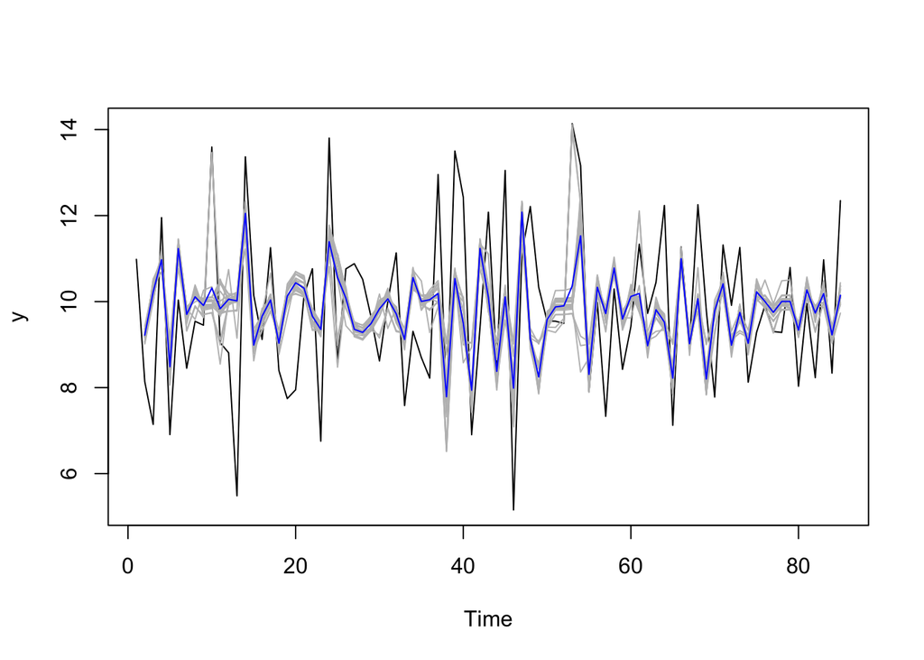

```r
fit.mlp.Zt = nnfor::mlp(tsnntrainZt, outplot= T, comb = "mean")
```

```r
fit.mlp.Zt
```

```
## MLP fit with 5 hidden nodes and 20 repetitions.
## Univariate lags: (1)
## Forecast combined using the mean operator.
## MSE: 2.7679.
```

```r
mlp.new.fore7 = forecast::forecast(fit.mlp.Zt, h = 10)
mlp.new.fore7
```

```
##    Point Forecast
## 86       8.072403
## 87      10.264458
## 88       9.618613
## 89      10.004903
## 90       9.711029
## 91       9.859453
## 92       9.762455
## 93       9.847908
## 94       9.769109
## 95       9.844041
```

- Combine observed new cases + forecast new cases

```r
Ztregress <- data.frame(c(nntrain$Zt, mlp.new.fore7$mean))
Ztregress
```

```
##    c.nntrain.Zt..mlp.new.fore7.mean.
## 1                          10.981659
## 2                           8.136002
## 3                           7.144216
## 4                          11.951530
## 5                           6.907318
## 6                          10.035407
## 7                           8.450565
## 8                           9.541315
## 9                           9.451236
## 10                         13.592128
## 11                          9.043774
## 12                          8.810474
## 13                          5.484124
## 14                         13.365214
```

[output cut: 81 more lines]

- Fit model for Xt w/ regressor of Zt

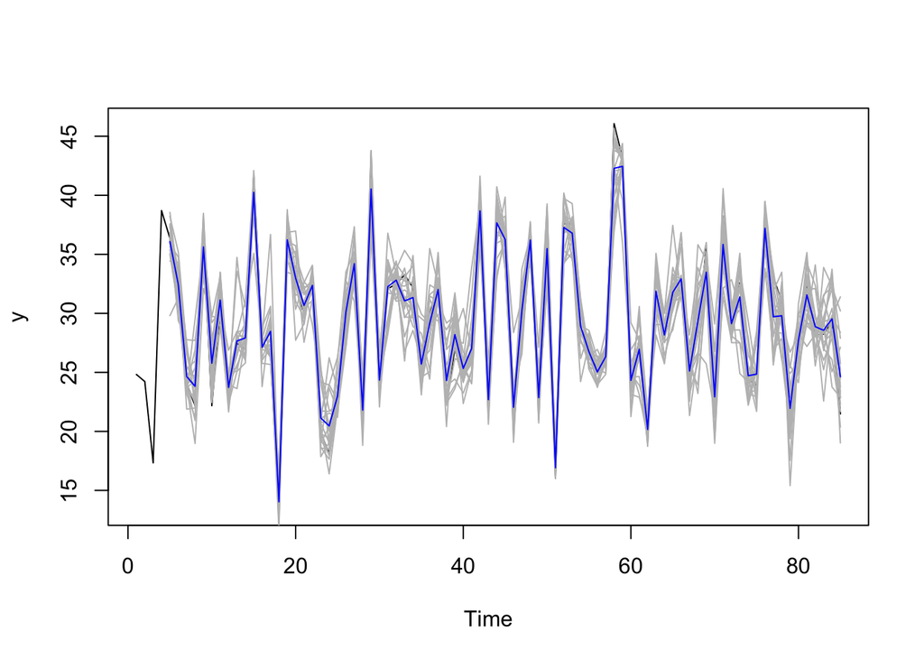

```r
mlp.Xt.fit = nnfor::mlp(tsnntrainXt, xreg =data.frame(tsnntrainZt), outplot = T, comb = "mean")
```

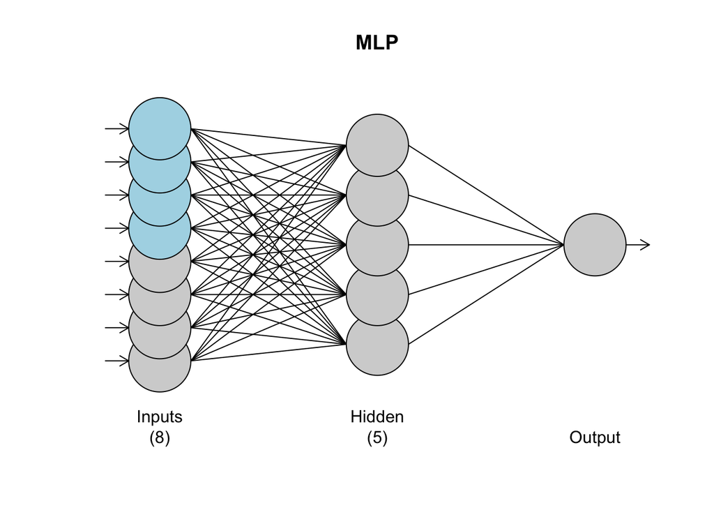

```r
plot(mlp.Xt.fit)
```

2. Provide a plot of the 10 forecasts (time points 96 – 105). You do not need prediction intervals for this question.

#### MLR

- Plot Predictions

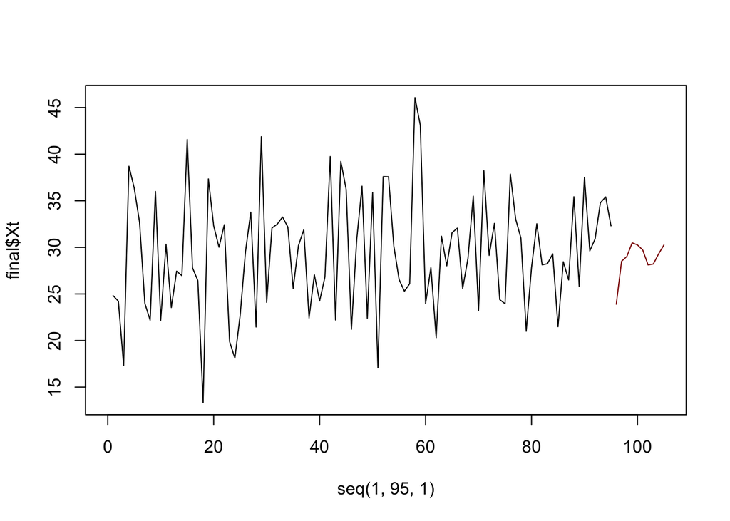

```r
plot(seq(1,95,1), final$Xt, type = "l", xlim = c(0,105))
lines(seq(96,105,1), predsXt$pred, type = "l", col = "dark red")
```

#### VAR

- Plot predictions w/ observed

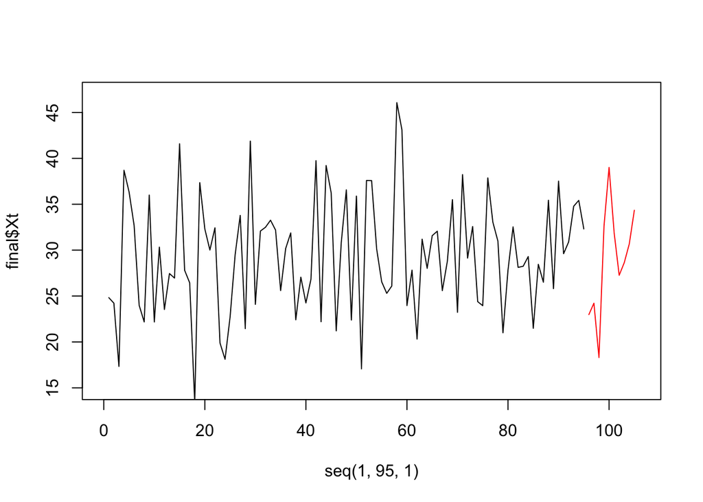

```r
plot(seq(1,95,1), final$Xt, type = "l", ylim = c(15,47), xlim = c(0,106))
lines(seq(96,105,1), forecasts10$fcst, type = "l", col= "red")
```

#### MLP

- Xt 10 Day Forecast w/ Zt Regressor

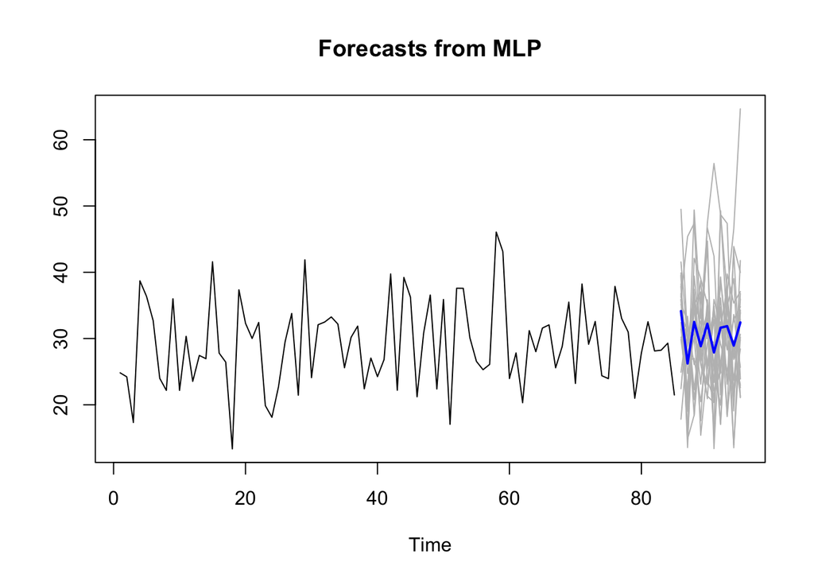

```r
Xtfore10 = forecast::forecast(mlp.Xt.fit, h = 10, xreg = Ztregress)
plot(Xtfore10)
```

3. Find the ASE for each model using the last 10 observations of the dataset. Include your code for this as well.

#### MLR

- ASE

```r
ASEmlr = mean((final$Xt[86:95] - predsXt$pred)^2)
ASEmlr
```

```
## [1] 23.305
```

#### VAR

- ASE

```r
ASEvar = mean((final$Xt[86:95] - forecasts10$fcst)^2)
ASEvar
```

```
## [1] 46.07396
```

#### MLP

- ASE

```r
ASEmlp = mean((final$Xt[86:95] - Xtfore10$mean)^2)
ASEmlp
```

```
## [1] 13.22629
```

3. Make a quick statement about which model you feel is most useful and why. (4 pts)